# TP5 — Principal Component Analysis (PCA) part 2

More PCA - heart failure dataset

Massimo Andreatta

2026-07-23

> **How to use this notebook.** You do **not** need any programming experience. Read each short explanation, then press the green *play* button (▶) at the top-right of each grey *code chunk* to run it. Look at the output, and answer the **Questions** in the green boxes (write your answers in plain text under each one). The goal is to *understand the data and the method*, not to memorise code.

> **Building on TP4.** This notebook assumes you have completed TP4, which introduced the core ideas of PCA using the hepatitis C dataset. Here we go further: we will look at how variable correlations motivate PCA, how binary clinical variables project onto PCA space, and how to think more carefully about what each principal component captures biologically.

# RECAP

## The problem: too many variables, too few dimensions

In medicine we routinely measure many things about each patient — blood tests, vital signs, imaging findings. When there are six, ten, or fifty measurements per patient, it becomes impossible to *see* the data: you cannot draw a 50-dimensional scatter plot. Yet a lot of information in those measurements is **redundant** — for example, two liver enzymes that always rise together carry roughly the same information.

**Principal Component Analysis (PCA)** exploits this redundancy to compress many variables into a small number of new variables — the **principal components** — that still capture most of the interesting variation. Think of it as finding the best angle from which to photograph a 3-D sculpture: you lose one dimension, but if you choose the right angle you preserve the important structure.

## What PCA can — and cannot — do

PCA is an **unsupervised** method: it looks only at the measurements, with no knowledge of clinical outcomes. It will find the directions of greatest variation, which may or may not align with what we care about clinically. When the main sources of biological variation *do* align with disease severity or prognosis, PCA makes that structure visible. When they do not (for instance, if the dominant variation is technical noise), PCA can mislead. Always interpret the components biologically before drawing conclusions.

## Key vocabulary

| Term | Plain-language meaning |
| --- | --- |
| **Principal component (PC)** | A new axis through the data; a weighted combination of the original variables |
| **Score** | A patient’s coordinate on a PC — where they sit along that axis |
| **Loading** | How much each original variable contributes to a PC (its “weight” on that axis) |
| **Variance explained** | The % of total spread captured by a PC — larger means more informative |
| **Scree plot** | A bar chart of variance explained by each PC, used to decide how many to keep |
| **Biplot** | A combined plot showing both patient scores and variable loadings |

# THE DATASET: HEART FAILURE CLINICAL RECORDS

Heart failure occurs when the heart cannot pump enough blood to meet the needs of the body. When the heart cannot pump properly, the body fails to get sufficient oxygen and nutrients.

This dataset contains clinical measurements from **299 heart failure patients** admitted to a hospital in Faisalabad, Pakistan (Ahmad T *et al.* 2017, *PLOS ONE*). Each row is one patient; each column is a clinical measurement or risk factor recorded at admission.

| Variable | Description | Units |
| --- | --- | --- |
| `age` | Age of the patient | years |
| `anaemia` | Decrease of red blood cells (0 = no, 1 = yes) | binary |
| `creatinine_phosphokinase` | CPK enzyme level — marker of muscle damage | mcg/L |
| `diabetes` | Whether the patient has diabetes (0/1) | binary |
| `ejection_fraction` | % of blood pumped out per heartbeat | % |
| `high_blood_pressure` | Hypertension (0/1) | binary |
| `platelets` | Platelet count | kiloplatelets/mL |
| `serum_creatinine` | Serum creatinine — marker of kidney function | mg/dL |
| `serum_sodium` | Serum sodium level | mEq/L |
| `sex` | Sex (0 = female, 1 = male) | binary |
| `smoking` | Smoking status (0/1) | binary |
| `time` | Follow-up period until death or end of study | days |
| `DEATH_EVENT` | Died during follow-up (0 = no, 1 = yes) | binary |

## Load the data

```r
hf <- read.csv("../data/CVD/heart_failure_clinical_records_dataset.csv")
head(hf)
```

```
##   age anaemia creatinine_phosphokinase diabetes ejection_fraction
## 1  75       0                      582        0                20
## 2  55       0                     7861        0                38
## 3  65       0                      146        0                20
## 4  50       1                      111        0                20
## 5  65       1                      160        1                20
## 6  90       1                       47        0                40
##   high_blood_pressure platelets serum_creatinine serum_sodium sex smoking time
## 1                   1    265000              1.9          130   1       0    4
## 2                   0    263358              1.1          136   1       0    6
## 3                   0    162000              1.3          129   1       1    7
## 4                   0    210000              1.9          137   1       0    7
## 5                   0    327000              2.7          116   0       0    8
## 6                   1    204000              2.1          132   1       1    8
##   DEATH_EVENT
## 1           1
## 2           1
## 3           1
## 4           1
## 5           1
## 6           1
```

# 1 — Meet the data

## Structure and variable types

The dimensionality of the dataset tells us how many patients and how many variables were measured

```r
dim(hf)
```

```
## [1] 299  13
```

The `str` command gives an overview of the dataset’s structure

```r
str(hf)
```

```
## 'data.frame':    299 obs. of  13 variables:
##  $ age                     : num  75 55 65 50 65 90 75 60 65 80 ...
##  $ anaemia                 : int  0 0 0 1 1 1 1 1 0 1 ...
##  $ creatinine_phosphokinase: int  582 7861 146 111 160 47 246 315 157 123 ...
##  $ diabetes                : int  0 0 0 0 1 0 0 1 0 0 ...
##  $ ejection_fraction       : int  20 38 20 20 20 40 15 60 65 35 ...
##  $ high_blood_pressure     : int  1 0 0 0 0 1 0 0 0 1 ...
##  $ platelets               : num  265000 263358 162000 210000 327000 ...
##  $ serum_creatinine        : num  1.9 1.1 1.3 1.9 2.7 2.1 1.2 1.1 1.5 9.4 ...
##  $ serum_sodium            : int  130 136 129 137 116 132 137 131 138 133 ...
##  $ sex                     : int  1 1 1 1 0 1 1 1 0 1 ...
##  $ smoking                 : int  0 0 1 0 0 1 0 1 0 1 ...
##  $ time                    : int  4 6 7 7 8 8 10 10 10 10 ...
##  $ DEATH_EVENT             : int  1 1 1 1 1 1 1 1 1 1 ...
```

Some variables are **continuous measurements** (age, ejection fraction, creatinine…); others are **binary flags** (diabetes, smoking, death event). PCA works on continuous numbers, so we separate them up front.

```r
# Continuous clinical measurements
cont_vars <- c("age", "creatinine_phosphokinase", "ejection_fraction",
               "platelets", "serum_creatinine", "serum_sodium")

# Binary variables — used later to *interpret* PCA, not as PCA input
bin_vars <- c("anaemia", "diabetes", "high_blood_pressure",
              "sex", "smoking", "DEATH_EVENT")
```

We also **exclude `time`** (follow-up length in days). Its value is partly determined by *when* a patient died — feeding it into PCA and then colouring by death outcome would be circular reasoning.

```r
summary(hf[, cont_vars])
```

```
##       age        creatinine_phosphokinase ejection_fraction   platelets
##  Min.   :40.00   Min.   :  23.0           Min.   :14.00     Min.   : 25100
##  1st Qu.:51.00   1st Qu.: 116.5           1st Qu.:30.00     1st Qu.:212500
##  Median :60.00   Median : 250.0           Median :38.00     Median :262000
##  Mean   :60.83   Mean   : 581.8           Mean   :38.08     Mean   :263358
##  3rd Qu.:70.00   3rd Qu.: 582.0           3rd Qu.:45.00     3rd Qu.:303500
##  Max.   :95.00   Max.   :7861.0           Max.   :80.00     Max.   :850000
##  serum_creatinine  serum_sodium
##  Min.   :0.500    Min.   :113.0
##  1st Qu.:0.900    1st Qu.:134.0
##  Median :1.100    Median :137.0
##  Mean   :1.394    Mean   :136.6
##  3rd Qu.:1.400    3rd Qu.:140.0
##  Max.   :9.400    Max.   :148.0
```

> **Question 1.1.** How many patients are in the dataset, and how many continuous variables will we use for PCA? What does `ejection_fraction` measure, and why might a value below 40 % be clinically worrying?

> **Question 1.2.** From the `summary()` output, which variable has the largest numerical range? Does a large range mean that variable is more *biologically important*, or is it simply a consequence of the units in which it is measured?

## Spotting skewed distributions and log-transforming

Right-skewed variables (a long right tail of very high values) can distort PCA — a handful of extreme patients would drag the axes. Let us inspect the two enzyme measurements.

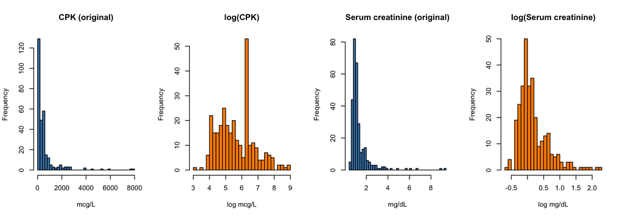

```r
par(mfrow = c(1, 4))
hist(hf$creatinine_phosphokinase, breaks = 40, col = "steelblue",
     main = "CPK (original)", xlab = "mcg/L")
hist(log(hf$creatinine_phosphokinase), breaks = 40, col = "darkorange",
     main = "log(CPK)", xlab = "log mcg/L")
hist(hf$serum_creatinine, breaks = 40, col = "steelblue",
     main = "Serum creatinine (original)", xlab = "mg/dL")
hist(log(hf$serum_creatinine), breaks = 40, col = "darkorange",
     main = "log(Serum creatinine)", xlab = "log mg/dL")
```

```r
par(mfrow = c(1, 1))
```

The log transformation makes both distributions far more symmetric. We work with the log-transformed versions from here on.

```r
hf$log_cpk       <- log(hf$creatinine_phosphokinase)
hf$log_creatinine <- log(hf$serum_creatinine)

cont_clean <- c("age", "log_cpk", "ejection_fraction",
                "platelets", "log_creatinine", "serum_sodium")
```

> **Question 1.3.** Why is it a good idea to log-transform heavily right-skewed variables *before* PCA? Hint: think about what happens to the Euclidean distance between patients when one variable spans a range of e.g. 1–1000 while another spans 100–150.

# 2 — Why standardise before PCA?

PCA finds the directions of **maximum variance**. If one variable has much larger numbers than another (e.g. platelet count in thousands vs. serum sodium in mEq/L), it will dominate the result simply because of its scale — not because it is more informative.

```r
round(apply(hf[, cont_clean], 2, sd, na.rm = TRUE), 3)
```

```
##               age           log_cpk ejection_fraction         platelets
##            11.895             1.134            11.835         97804.237
##    log_creatinine      serum_sodium
##             0.453             4.412
```

```r
X <- scale(hf[, cont_clean])    # standardise to mean 0, sd 1

round(apply(X, 2, mean), 3)     # confirm: all ≈ 0
```

```
##               age           log_cpk ejection_fraction         platelets
##                 0                 0                 0                 0
##    log_creatinine      serum_sodium
##                 0                 0
```

```r
round(apply(X, 2, sd),   3)     # confirm: all = 1
```

```
##               age           log_cpk ejection_fraction         platelets
##                 1                 1                 1                 1
##    log_creatinine      serum_sodium
##                 1                 1
```

After standardisation every variable contributes on equal footing: we compare *patterns of variation*, not raw magnitudes.

> **Question 2.1.** Before scaling, which variable has the largest standard deviation? If we ran PCA on the raw numbers, which variable would likely dominate PC1 — and would that reflect biology or something else?

> **Question 2.2.** After standardisation, a patient has a value of +2 for `ejection_fraction`. What does that mean in plain English — how does this patient compare to the rest of the cohort?

# 3 — Running PCA

## Computing the principal components

`prcomp()` rotates the data so that the first axis (**PC1**) captures as much variance as possible, the second (**PC2**) captures as much of the *remaining* variance as possible, and so on. The total number of PCs equals the number of input variables (here, six).

```r
pca <- prcomp(X, scale. = FALSE)   # already scaled above
summary(pca)
```

```
## Importance of components:
##                           PC1    PC2    PC3    PC4    PC5    PC6
## Standard deviation     1.2069 1.0869 0.9895 0.9578 0.8885 0.8222
## Proportion of Variance 0.2428 0.1969 0.1632 0.1529 0.1316 0.1127
## Cumulative Proportion  0.2428 0.4397 0.6029 0.7558 0.8873 1.0000
```

The row **Proportion of Variance** tells us how much of the total information each PC captures.

# 4 — Patients in PCA space

## The PCA plot

Each patient becomes a **single point** in PCA space. Points close together are clinically similar across all six measurements; points far apart differ substantially. Crucially, the PCA was computed without any knowledge of who died — we now colour the points by outcome to see whether the structure aligns with survival.

```r
scores <- as.data.frame(pca$x)
scores$death <- factor(hf$DEATH_EVENT, levels = c(0, 1),
                       labels = c("Survived", "Died"))
```

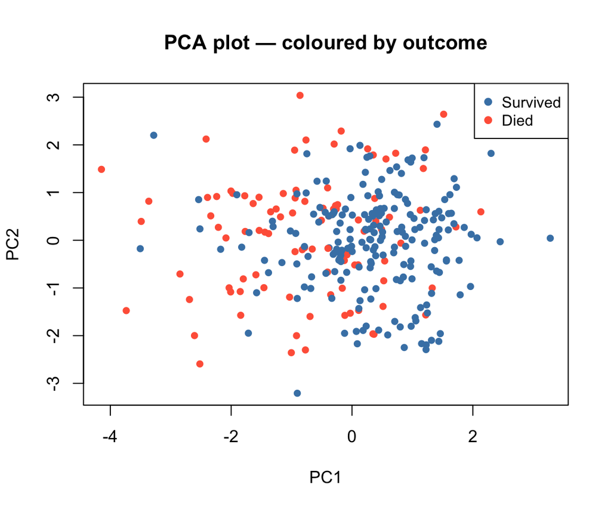

```r
col_death <- ifelse(scores$death == "Died", "tomato", "steelblue")

plot(scores$PC1, scores$PC2,
     col = col_death, pch = 19, cex = 0.8,
     xlab = "PC1", ylab = "PC2",
     main = "PCA plot — coloured by outcome")
legend("topright", legend = c("Survived", "Died"),
       col = c("steelblue", "tomato"), pch = 19, cex = 0.9)
```

> **Question 4.1.** Do patients who died tend to cluster in a specific region of the PC1–PC2 plane? Is the separation between survivors and non-survivors perfect, or is there considerable overlap? What does substantial overlap tell us about the complexity of predicting heart failure outcomes from these measurements alone?

## Mapping individual clinical variables onto the PCA

We can colour the same point cloud by any continuous measurement to reveal which variable “explains” the position of patients along each PC axis.

```r
# Helper: map numeric values to a blue-white-red gradient
map_color <- function(x, n = 100) {
  pal <- colorRampPalette(c("blue", "white", "red"))(n)
  idx <- cut(x, breaks = n, labels = FALSE, include.lowest = TRUE)
  pal[idx]
}
```

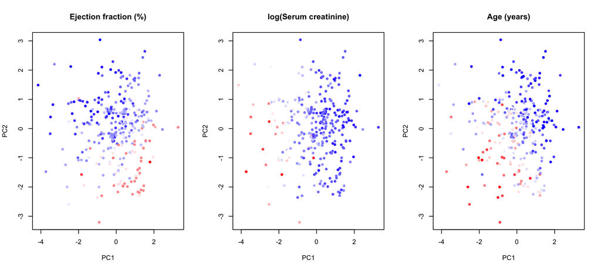

```r
par(mfrow = c(1, 3))

plot(scores$PC1, scores$PC2, pch = 19, cex = 0.7,
     col = map_color(hf$ejection_fraction),
     main = "Ejection fraction (%)", xlab = "PC1", ylab = "PC2")

plot(scores$PC1, scores$PC2, pch = 19, cex = 0.7,
     col = map_color(hf$log_creatinine),
     main = "log(Serum creatinine)", xlab = "PC1", ylab = "PC2")

plot(scores$PC1, scores$PC2, pch = 19, cex = 0.7,
     col = map_color(hf$age),
     main = "Age (years)", xlab = "PC1", ylab = "PC2")
```

```r
par(mfrow = c(1, 1))
```

*In all plots: blue = low values, red = high values.*

> **Question 4.2.** Are these variables higher/lower in the same regions of the plot? what does that say about their correlation?

## Plotting binary variables in PCA space

The dataset also contains **binary clinical flags** — anaemia, diabetes, high blood pressure, smoking, and sex. PCA was computed from the six *continuous* measurements, but we can still ask: do patients with a given condition tend to cluster in a particular region of PCA space?

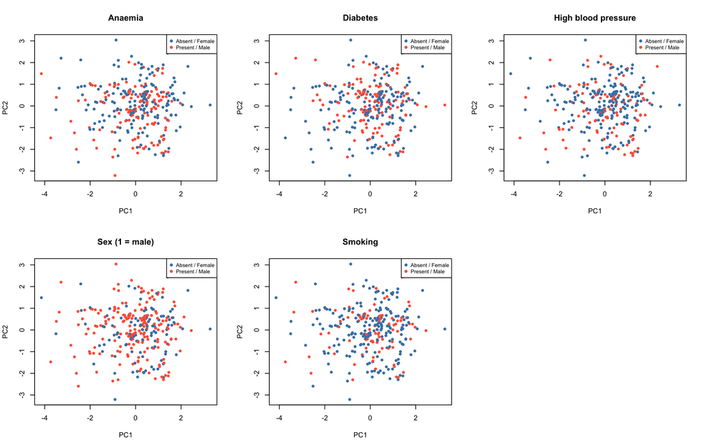

```r
bin_labels <- c("anaemia", "diabetes", "high_blood_pressure", "sex", "smoking")
bin_titles <- c("Anaemia", "Diabetes", "High blood pressure",
                "Sex (1 = male)", "Smoking")

bin_col <- c("0" = "steelblue", "1" = "tomato")

par(mfrow = c(2, 3))
for (i in seq_along(bin_labels)) {
  grp <- as.character(hf[[ bin_labels[i] ]])
  plot(scores$PC1, scores$PC2,
       col = bin_col[grp], pch = 19, cex = 0.7,
       main = bin_titles[i],
       xlab = "PC1", ylab = "PC2")
  legend("topright", legend = c("Absent / Female", "Present / Male"),
         col = bin_col, pch = 19, cex = 0.75)
}
par(mfrow = c(1, 1))
```

> **Question 4.3.** For which binary variables (if any) do you see a clear spatial separation in PCA space — i.e., one group clustering on a particular side of PC1 or PC2? What does this tell us about whether those conditions are associated with the main axes of clinical variation in this cohort?

# 5 — What drives each PC?

The **loadings** (stored in `pca$rotation`) tell us how much each original variable contributes to each PC. A large positive loading means patients with high values of that variable sit at the *positive* end of the PC; a large negative loading places them at the *negative* end.

```r
round(pca$rotation[, 1:4], 3)
```

```
##                      PC1    PC2    PC3    PC4
## age               -0.385 -0.523  0.020 -0.475
## log_cpk            0.162  0.514  0.164 -0.812
## ejection_fraction  0.307 -0.606  0.024 -0.184
## platelets          0.241 -0.091  0.937  0.147
## log_creatinine    -0.616 -0.114  0.236 -0.132
## serum_sodium       0.543 -0.271 -0.196 -0.206
```

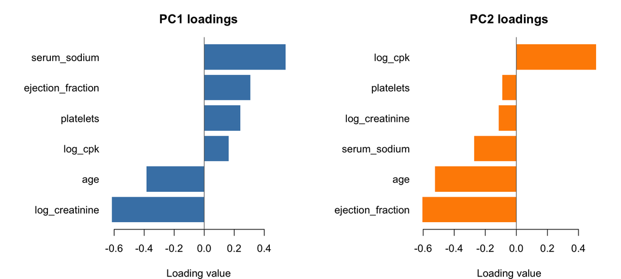

```r
par(mfrow = c(1, 2), mar = c(4, 9, 3, 2))

barplot(sort(pca$rotation[, 1]),
        horiz = TRUE, las = 1, col = "steelblue", border = NA,
        main = "PC1 loadings", xlab = "Loading value")
abline(v = 0, col = "grey40")

barplot(sort(pca$rotation[, 2]),
        horiz = TRUE, las = 1, col = "darkorange", border = NA,
        main = "PC2 loadings", xlab = "Loading value")
abline(v = 0, col = "grey40")
```

```r
par(mfrow = c(1, 1))
```

## The sign of a loading and the sign of a PC score

A subtlety worth understanding: the **direction** of a PC axis (which end is “positive” and which is “negative”) is mathematically arbitrary. PCA can flip an axis and the result is equally valid — the relative positions of patients do not change. This means you should always interpret the *sign* of a loading in the context of the other loadings on the same PC: what matters is whether two variables load in the **same** or **opposite** direction, not whether the loading is positive or negative in isolation.

> **Question 5.1.** Looking at the PC1 loading barplot, which variables have the strongest positive and negative loadings? Based on these, propose a biological interpretation for PC1: is it primarily an axis of *kidney function*, *cardiac function*, or a contrast between the two?

> **Question 5.2.** Do `ejection_fraction` and `log_creatinine` have loadings of the same sign or opposite signs on PC1? A failing heart pumps less blood to the kidneys, causing creatinine to rise — so patients with low ejection fraction often have high serum creatinine. Does the loading barplot reflect this clinical anti-correlation?

> **Question 5.3.** Which variables load most strongly on PC2? What might PC2 represent? (Hint: look at which variables are *not* well captured by PC1 and therefore have most of their signal in PC2.)

> **Question 5.4.** How would you change the code to also look at PC3 or PC4? How many PCs does it make sense to analyze? How many total PCs are there?

# 6 — Wrap-up

> **Question 6.1 (wrap-up).** In four or five sentences, summarise the key findings: What are the main axes of variation among these heart failure patients? Which clinical measurements drive those axes, and how do they relate to each other biologically? Do patients who died occupy a distinct region of PCA space?